# An Exploratory Analysis of Police Acquisition of Militarized Equipment

## Introduction

The United States Defence Department’s [1033 program](https://en.wikipedia.org/wiki/1033_program) began in 1997, it allows for the transfer of excess military equipment to civilian law enforcement agencies. Most of the equipment obtained is standard, things such as cold weather clothing, deisel generators and flashlights. However, a significant portion of it is explicitly combat-oriented in nature, equipment such as M-16 rifles, tanks, and mine-resistant vehicles.

This is an analysis that explores U.S. civilian law enforcement spending on the acquisition of military equipment that is explicitly combat-oriented. Spending is examined at a state and county level, other county-level data such as crime and poverty rates are incorporated and their relationship to spending is also investigated.

Please e-mail comments and suggestions to vcolano@gmail.com.

## About the data

The New York Times filed a freedom of information act request and received data from the Pentagon on all acquisitions since 2006. The data was made public by the NYT and can be found [here](https://github.com/TheUpshot/Military-Surplus-Gear). The NYT wrote a post with an interactive data visualization on the topic: [What Military Gear Your Local Police Department Bought](https://www.nytimes.com/2014/08/20/upshot/data-on-transfer-of-military-gear-to-police-departments.html).

## Setup

Load libraries and import the police acquisitions data set.

```r
library(data.table)
library(ggplot2)
library(scales)
library(ggmap)
library(statebins)
library(plyr)
library(readxl)
library(stringr)
library(stringi)
library(extrafont)
library(USA.county.data)
library(lattice)
#library(devtools)
#devtools::install_github("deleetdk/USA.county.data") # only need to load this once
data = fread("~/projects/policeMilitarySurplus/data/policeAcquisitionOfMilitarySurplus2014.csv")
colnames(data) = make.names(names(data)) # make column names R-friendly (remove spaces)
data$Item.Name = sapply(data$Item.Name, trimws) # trim whitespace
data = data[!(data$Item.Name == ""), ] # get rid of empty string value
# make an appropriate theme for our plots later on
military_theme = theme_classic() +
  theme(plot.title=element_text(size=20, color="#0D0A0B", vjust=1, hjust=0.5, family="Courier New"),
  text=element_text(size=13, hjust=0.5, family="Courier New"), plot.background=element_rect(color="#F3EFF5"))
```

Dataset format:

```r
head(data, n=1)
```

| State | County | NSN | Item.Name | Quantity | UI | Acquisition.Cost | Ship.Date |
| --- | --- | --- | --- | --- | --- | --- | --- |
| AK | ANCHORAGE | 1005-00-073-9421 | RIFLE,5.56 MILLIMETER | 1 | Each | 499 | 2012-08-30 |

NSN stands for NATO Stock Number, it’s a unique identifier for military supplies across NATO nations

## Which items were purchased the most?

```r
itemFreq = count(data, "Item.Name")
itemFreq = itemFreq[with(itemFreq, order(-freq)), ]
head(itemFreq, n=10)
```

|  | Item.Name | freq |
| --- | --- | --- |
| 12840 | RIFLE,5.56 MILLIMETER | 61548 |
| 12841 | RIFLE,7.62 MILLIMETER | 17726 |
| 13951 | SIGHT,REFLEX | 9494 |
| 11529 | PISTOL,CALIBER .45,AUTOMATIC | 8649 |
| 16300 | TRUCK,UTILITY | 5002 |
| 10680 | NIGHT VISION GOGGLE | 2279 |
| 8208 | ILLUMINATOR,INFRARED | 2275 |
| 13799 | SHIRT,COLD WEATHER | 2085 |
| 8217 | IMAGE INTENSIFIER,NIGHT VISION | 1870 |
| 13887 | SHOTGUN,12 GAGE,RIOT TYPE | 1448 |

## Total expenditure on an item-level basis

```r
costs_df = itemFreq
costs_df$freq = costs_df$freq + (1 - data$Quantity[match(costs_df$Item.Name, data$Item.Name)])
costs_df$Total.Cost = data$Acquisition.Cost[match(costs_df$Item.Name, data$Item.Name)]
costs_df$Total.Cost = costs_df$Total.Cost*costs_df$freq
costs_df$NSN = data$NSN[match(costs_df$Item.Name, data$Item.Name)] # NSN will be useful to us
costs_df = costs_df[c("NSN", "Item.Name", "freq", "Total.Cost")] # reorder for readability
costs_df = costs_df[with(costs_df, order(-Total.Cost)), ]
head(costs_df, n=20)
```

|  | NSN | Item.Name | freq | Total.Cost |
| --- | --- | --- | --- | --- |
| 16300 | 2320-01-146-7190 | TRUCK,UTILITY | 5002 | 195868316 |
| 10136 | 2355-01-555-0908 | MINE RESISTANT VEHICLE | 341 | 140492000 |
| 7752 | 1520-00-087-7637 | HELICOPTER,UTILITY | 109 | 100574736 |
| 7750 | 1520-01-020-4216 | HELICOPTER,OBSERVATION | 282 | 53810394 |
| 16296 | 2320-01-272-5029 | TRUCK TRACTOR | 547 | 53661247 |
| 16224 | 2320-01-050-2084 | TRUCK,CARGO | 718 | 50700134 |
| 10829 | 2355-DS-COM-BTV2 | ONLY COMPLETE COMBAT/ASSAULT/TACTICAL WHEELED VEHICLES | 98 | 45080000 |
| 16250 | 3930-01-054-3833 | TRUCK,LIFT,FORK | 309 | 30903090 |
| 12840 | 1005-00-073-9421 | RIFLE,5.56 MILLIMETER | 61548 | 30712452 |
| 16234 | 2320-01-047-8756 | TRUCK,DUMP | 355 | 30016670 |

[output cut: 10 more lines]

$195,868,316 spent on Humvee-like trucks, $140,492,000 on mine-resistant trucks and $100,574,736 on helicopters were the three largest expenses.

## Extracting a purely-militarized subset

There is some equipment which is objectively non-militarized, such as the dump trucks, fork lifts and diesel generators. To focus this analysis on the militarization of US police forces we’ll reduce the data to a subset that is explicitly militarized in nature, items which could serve little to no purpose in the policing of civilians. For simplicity, only the first 100 items with the highest total cost were examined manually. Other items containing keywords which indicate that they are militarized are also added.

Disclaimer: There is subjectivity as to what is “militarized” and what is not. While items were thoroughly researched by looking up their NSN, the author does not have significant knowledge of this domain.

```r
subset = c("TRUCK,UTILITY",  "MINE RESISTANT VEHICLE", "ONLY COMPLETE COMBAT/ASSAULT/TACTICAL WHEELED VEHICLES",
           "RIFLE,5.56 MILLIMETER", "ILLUMINATOR,INFRARED", "TRUCK,CARGO", "TRUCK,VAN",
           "CARRIER,PERSONNEL,FULL TRACKED", "TRUCK,ARMORED", "FORWARD LOOKING INFRARED IMAGING SYSTEM",
           "TRUCK,WRECKER", "NIGHT VISION GOGGLE", "VIEWER,NIGHT VISION", "BOAT,BRIDGE ERECTION,INBOARD ENGINE",
           "LIGHT ARMORED VEHICLE", "RANGE FINDER,LASER", "SIGHT,REFLEX",
           "SHOP EQUIPMENT,AUTOMOTIVE VEHICLE", "TRUCK,STAKE", "RIFLE,7.62 MILLIMETER", "MINE RESISTANT VEHI",
           "TRUCK,TANK", "SIGHT,NIGHT VISION SNIPERSCOPE", "SEMITRAILER,TANK")
subset = c(subset, unique(data$Item.Name[with(data, grepl("RIFLE", Item.Name))]))
subset = c(subset, unique(data$Item.Name[with(data, grepl("TANK", Item.Name))]))
subset = c(subset, unique(data$Item.Name[with(data, grepl("GRENADE", Item.Name))]))
subset = c(subset, unique(data$Item.Name[with(data, grepl("BAYONET", Item.Name))]))
subset = unique(subset) # remove duplicates
subset_df = data[data$Item.Name %in% subset]
```

```r
sum(subset_costs_df$Total.Cost)/sum(costs_df$Total.Cost)
```

```
[1] 0.4818525
```

All in all, there are 175 unique items in the subset with a total cost of $609,879,850. Out of all spending 48% of it was combat-oriented in nature.

## State-level analysis

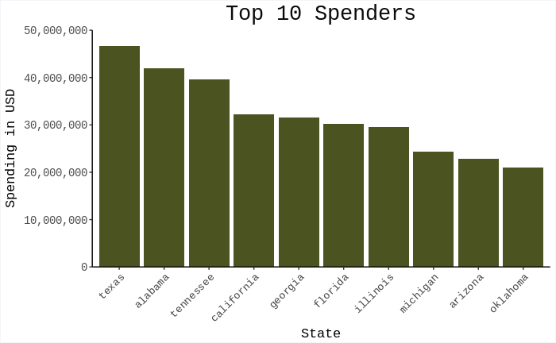

```r
# Reshape data onto a state level
states_df = aggregate(subset_df$Acquisition.Cost, by=list(state=subset_df$State), FUN=sum)
names(states_df)[names(states_df) == 'x'] = 'spending'
states_df$stateAbr = states_df$state
states_df$state = sapply(state.name[match(states_df$state, state.abb)], tolower)
states_df = states_df[complete.cases(states_df),]
# see who spent the most
suppressWarnings(
ggplot(data = head(states_df[order(-states_df$spending), ], n=10), aes(reorder(state, -spending), spending)) +
  geom_histogram(stat="identity", fill="#4b5320") + # army green
  scale_x_discrete() +
  scale_y_continuous(labels = comma, limits = c(0, 50000000),  expand=c(0,0)) +
  military_theme + theme(axis.text.x = element_text(angle=45, hjust=1)) +
  xlab("State") + ylab("Spending in USD") + ggtitle("Top 10 Spenders"))
```

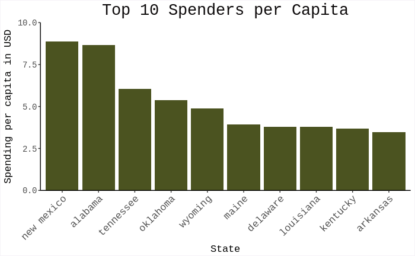

```r
# Adjust for population
states_pop = fread("~/projects/policeMilitarySurplus/data/statePopulation.csv")
states_df$spendingPerCapita = states_df$spending / states_pop[match(states_df$state, sapply(states_pop$state, tolower))]$pop_est_2014
suppressWarnings(
ggplot(data = head(states_df[order(-states_df$spendingPerCapita), ], n=10), aes(reorder(state, -spendingPerCapita), spendingPerCapita)) +
  geom_histogram(stat="identity", fill="#4b5320") +
  scale_x_discrete() +
  scale_y_continuous(labels = comma, limits = c(0, 10), expand=c(0,0)) +
  military_theme +
  theme(axis.text.x = element_text(angle=45, hjust=1, size = 12)) +
  xlab("State") + ylab("Spending per capita in USD") +
  ggtitle("Top 10 Spenders per Capita"))
```

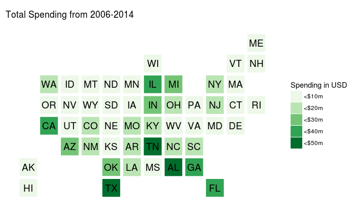

```r
# let's see this on a map
suppressWarnings(
statebins(states_df, "stateAbr", "spending", legend_position = "right", breaks=5,
                     labels=c("<$10m","<$20m","<$30m","<$40m","<$50m"), font_size = 5, legend_title="Spending in USD",
                     brewer_pal = "Greens", text_color = "black",
                     plot_title = "Total Spending from 2006-2014",
                     title_position = "top"))
```

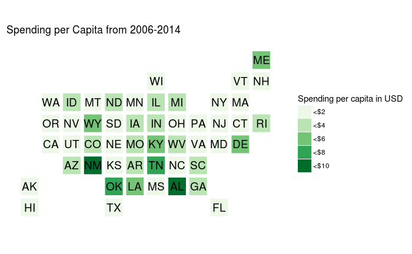

```r
suppressWarnings(
statebins(states_df, "stateAbr", "spendingPerCapita", legend_position = "right",
                     legend_title="Spending per capita in USD", font_size = 5,
                     breaks = 5, labels=c("<$2","<$4","<$6","<$8","<$10"),
                     brewer_pal = "Greens", text_color = "black",
                     plot_title = "Spending per Capita from 2006-2014",
                     title_position = "top"))
```

## County-level analysis

|  | county | state | spending |
| --- | --- | --- | --- |
| 35 | jefferson | alabama | 8112570 |
| 74 | maricopa | arizona | 6363911 |
| 1405 | monmouth | new jersey | 5340412 |
| 542 | lake | illinois | 4800179 |
| 516 | cook | illinois | 4656017 |
| 161 | los angeles | california | 4575273 |
| 27 | etowah | alabama | 4173705 |
| 78 | pinal | arizona | 3939089 |
| 8 | calhoun | alabama | 3825812 |
| 2073 | harris | texas | 3781767 |

[output not shown]

```r
# There are 3144 counties in the US (https://en.wikipedia.org/wiki/List_of_counties_by_U.S._state)
print(length(counties_df$county)) # Counties with spending > 0
```

```
[1] 2378
```

```r
print(length(counties_df$county)/3144)
```

```
[1] 0.7563613
```

Out of the 3144 counties in the US, 2378, or 75%, had some spending on militarized equipment. Counties which have spent nothing on militarized equipment are not taken into account in the following analyses.

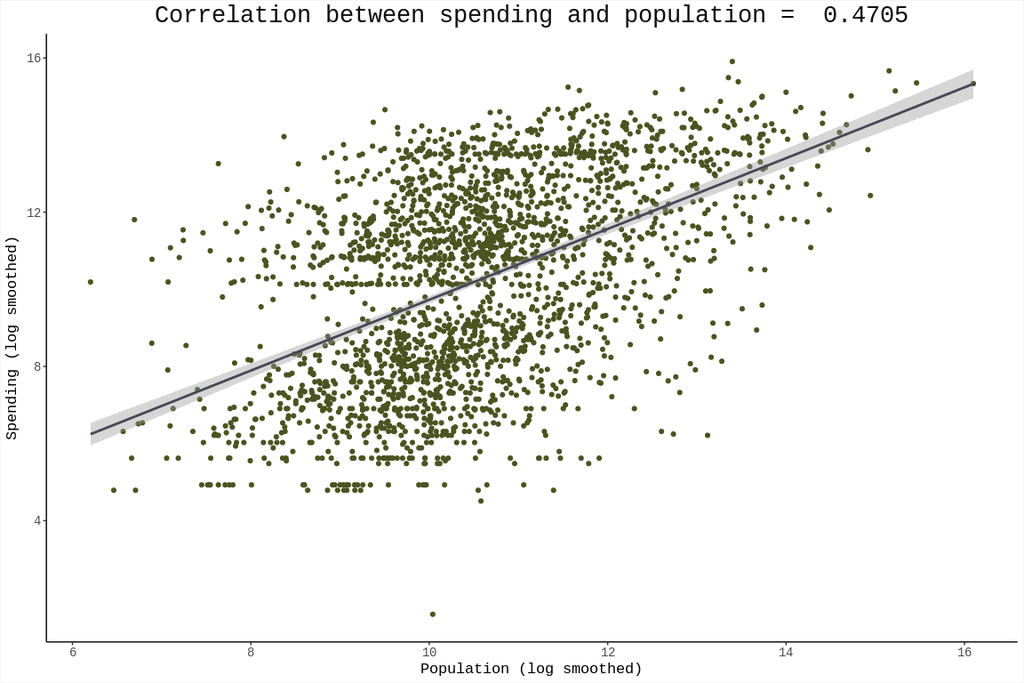

```r
# Is population correlated with spending?
spendPopCor = format(cor(counties_df$population, counties_df$spending, use = "complete"), digits = 4)
suppressWarnings(
ggplot(data = counties_df, aes(x = log(counties_df$population), y = log(counties_df$spending))) +
  military_theme + xlab("Population (log smoothed)") +
  ylab("Spending (log smoothed)") +
  geom_point(colour="#4b5320") + geom_smooth(method='lm', formula=y~x, colour="#454955") +
  ggtitle(paste("Correlation between spending and population = ", spendPopCor)))
```

The correlation coefficient of 0.47 implies that there is a positive relationship between a county’s police departments’ spending on militarized equipment and the county’s population. In simpler terms, counties with more people tend to have more militarized equipment.

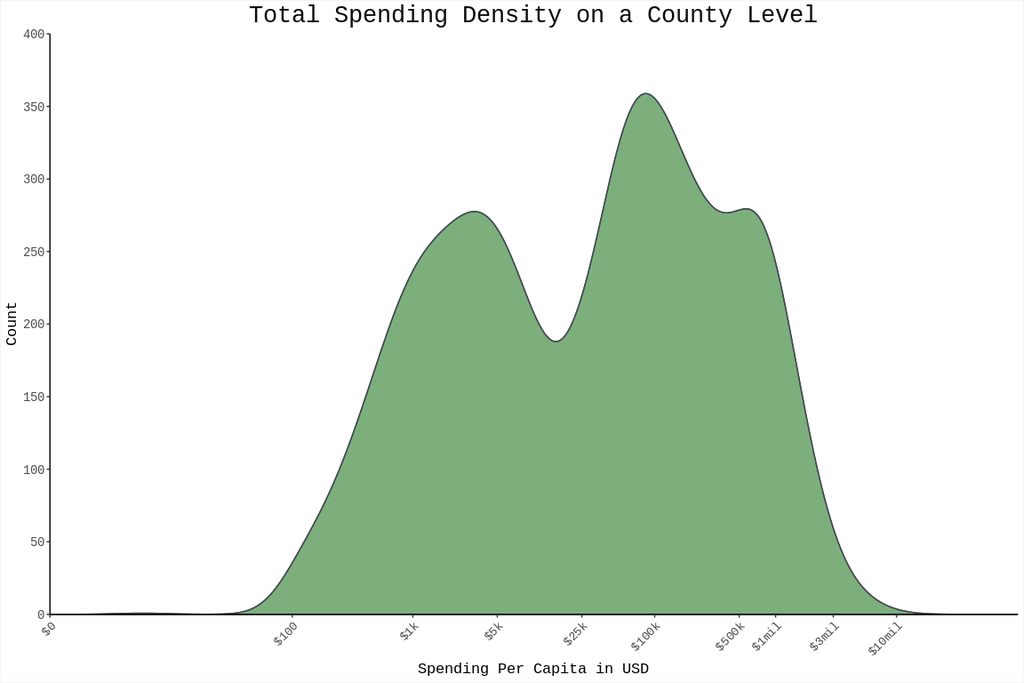

```r
# plot distribution of spending
suppressWarnings(
ggplot(data = counties_df, aes(x=counties_df$spending)) +
  stat_density(aes(y=..count..), color="#454955", fill="dark green", alpha=0.3) +
  stat_density(aes(y=..count..), color="#454955", fill="dark green", alpha=0.3) +
  scale_x_continuous(breaks=c(0, 100, 1000, 5000, 25000, 100000, 500000, 1000000, 3000000, 10000000),
                     labels=c("$0","$100","$1k","$5k","$25k","$100k","$500k","$1mil","$3mil","$10mil"),
                     trans="log1p", expand=c(0,0), limits=c(0,100000000)) +
  scale_y_continuous(breaks=c(0, 50, 100, 150, 200, 250, 300, 350, 400), expand=c(0,0), limits=c(0,400)) +
  military_theme + xlab("Spending Per Capita in USD") + ylab("Count") +
  theme(axis.text.x = element_text(angle=45, hjust=1)) +
  ggtitle("Total Spending Density on a County Level"))
```

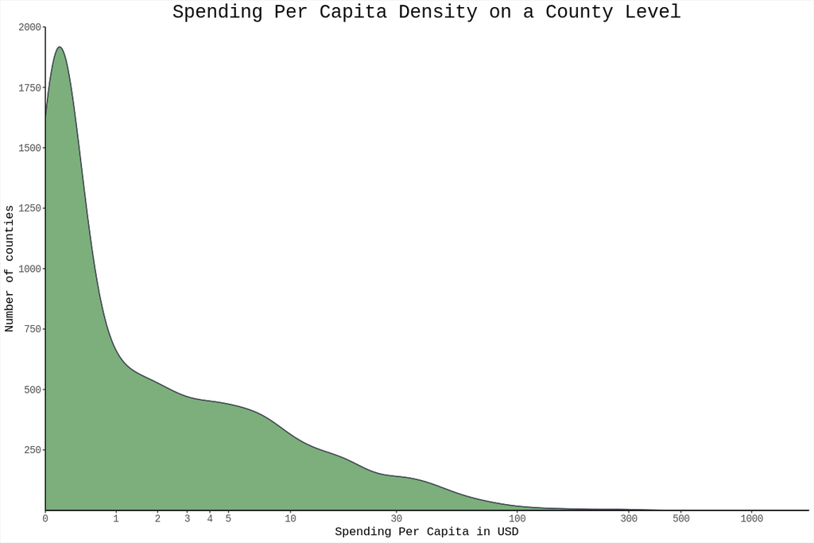

```r
# plot distribution of spending per capita
suppressWarnings(
ggplot(data = counties_df, aes(x=counties_df$spendingPerCapita)) +
  stat_density(aes(y=..count..), color="#454955", fill="dark green", alpha=0.3) +
  stat_density(aes(y=..count..), color="#454955", fill="dark green", alpha=0.3) +
  scale_x_continuous(breaks=c(-1,0,1,2,3,4,5,10,30,100,300,500,1000), trans="log1p", expand=c(0,0), limits=c(0,1750)) +
  scale_y_continuous(breaks=c(250,500,750,1000,1250,1500,1750,2000), expand=c(0,0), limits=c(0,2000)) +
  military_theme + xlab("Spending Per Capita in USD") + ylab("Number of counties") +
  ggtitle("Spending Per Capita Density on a County Level"))
```

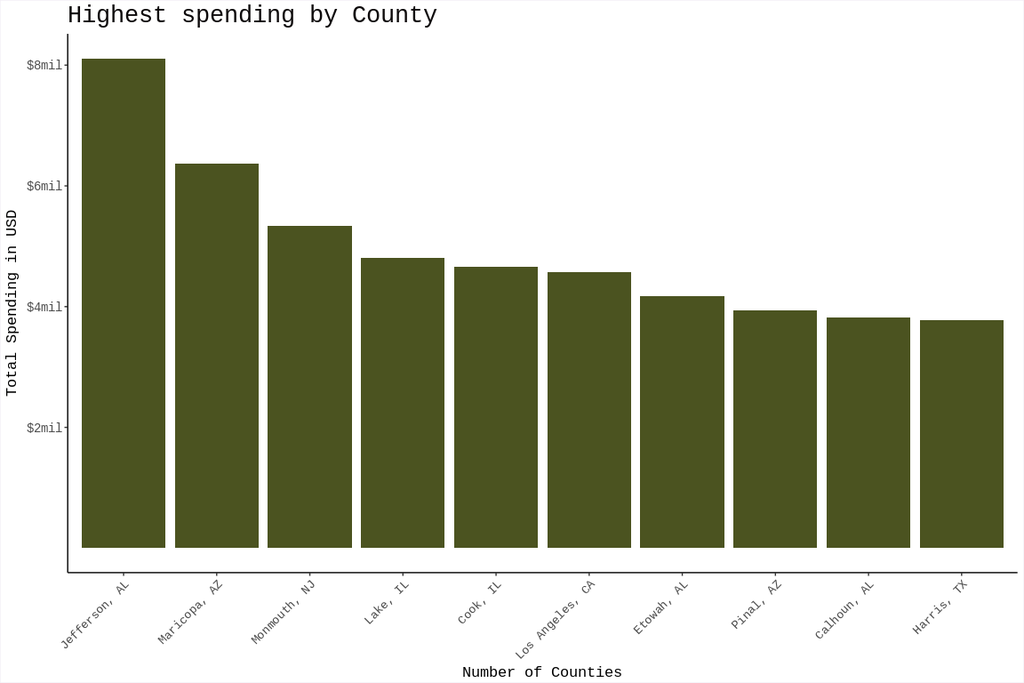

```r
# plot the counties which spent the most
suppressWarnings(
ggplot(data = highest_spenders, aes(x=reorder(Area_name, -spending), y=spending)) +
  geom_histogram(stat="identity", fill="#4b5320") +
  scale_y_continuous(breaks=c(2000000, 4000000, 6000000, 8000000),
                     labels=c("$2mil", "$4mil", "$6mil", "$8mil")) +
  military_theme + theme(axis.text.x = element_text(angle=45, hjust=1), plot.title = element_text(hjust = 0)) +
  xlab("Number of Counties") + ylab("Total Spending in USD") +
  ggtitle("Highest spending by County"))
```

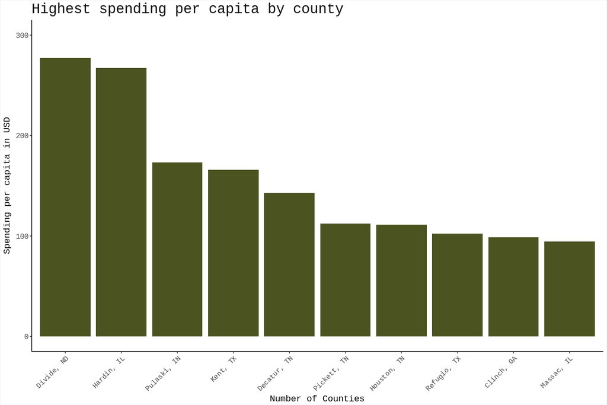

```r
# plot the counties which spent the most per capita
suppressWarnings(
ggplot(data = head(counties_df[order(-counties_df$spendingPerCapita), ], n=10), aes(reorder(county, -spendingPerCapita), spendingPerCapita)) +
  geom_histogram(stat="identity", fill="#4b5320") +
  scale_x_discrete(labels=counties_df$Area_name) +
  scale_y_continuous(labels = comma, limits = c(0, 300)) +
  military_theme + theme(axis.text.x = element_text(angle=45, hjust=1), plot.title = element_text(hjust = 0)) +
  xlab("Number of Counties") + ylab("Spending per capita in USD") +
  ggtitle("Highest spending per capita by county"))
```

Most of these counties are very rural with populatiosn under 5000, a couple large purchases (such as 2 tanks and 4 trucks in the case of Divide, ND) give them their high spending per capita.

## Bringing in external county-level data

This data comes from three sources:  
1. [US Census County Data](https://www.census.gov/support/USACdataDownloads.html#RHI)  
2. [2012 Presidential Election County-Level Data from The Guardian](https://www.theguardian.com/news/datablog/2012/nov/07/us-2012-election-county-results-download#data)  
3. [A Multifactor US County-Level Dataset](https://github.com/Deleetdk/USA.county.data) put together by [Emil O. W. Kirkegaard](https://openpsych.net/person/1) for his 2016 paper [Inequality across US counties: an S factor analysis](https://openpsych.net/paper/12) * The factors in this data set do not have detailed descriptions and it has no data from 2008-2012, though most of the factors are from other time spans in between 2006-2014. Only factors with titles that were easily interpretable are used.

```r
# Population density in 2010
pop_dense_df = read_excel("~/projects/policeMilitarySurplus/data/censusCountyPopulationTotal1.xls", sheet = 3)
counties_df$popDensity = pop_dense_df$POP060210D[match(counties_df$Area_name, pop_dense_df$Area_name)]
spendPopDenseCor = format(cor(counties_df$popDensity, counties_df$spending, use = "complete"), digits = 4)
# Crime
crime_df = read_excel("~/projects/policeMilitarySurplus/data/censusCountyCrime1.xls", sheet = 3)
# Averge number of violent crimes per year known to police over 2006, 2007 and 2008
counties_df$crime= (crime_df$CRM110208D[match(counties_df$Area_name, crime_df$Areaname)] +
                    crime_df$CRM110207D[match(counties_df$Area_name, crime_df$Areaname)] +
                    crime_df$CRM110208D[match(counties_df$Area_name, crime_df$Areaname)]) / 3
spendCrimeCor = format(cor(counties_df$crime, counties_df$spending, use = "complete"), digits = 4)
# Poverty
income_pov_df = read_excel("~/projects/policeMilitarySurplus/data/censusCountyIncomeAndPovertyData.xls", sheet = 3)
# Average people of all ages in poverty per year from 2006-2009
counties_df$poverty = (income_pov_df$IPE110209D[match(counties_df$Area_name, income_pov_df$Areaname)] +
                         income_pov_df$IPE110208D[match(counties_df$Area_name, income_pov_df$Areaname)] +
                         income_pov_df$IPE110207D[match(counties_df$Area_name, income_pov_df$Areaname)] +
                         income_pov_df$IPE110206D[match(counties_df$Area_name, income_pov_df$Areaname)]) / 4
spendPovCor = format(cor(counties_df$poverty, counties_df$spending, use = "complete"), digits = 4)
# Bring in a huge set of count-level data from https://github.com/Deleetdk/USA.county.data
data(USA_county_data)
counties_df$fips = election_df$FIPS[match(counties_df$Area_name, election_df$Area_name)]
USA_county_delta = USA_county_data[sapply(USA_county_data, is.numeric)]
USA_county_delta$spending = counties_df$spending[match(USA_county_delta$fips, counties_df$fips)]
USA_county_delta$percentVotersVotedRomney2008 = counties_df$percentRomney[match(USA_county_delta$fips, counties_df$fips)]
USA_county_delta$popDensity2010 = counties_df$popDensity[match(USA_county_delta$fips, counties_df$fips)]
USA_county_delta$avgViolentCrime06to08 = counties_df$crime[match(USA_county_delta$fips, counties_df$fips)]
USA_county_delta$avgNumPeopleInPoverty06to09 = counties_df$population[match(USA_county_delta$fips, counties_df$fips)]
USA_county_delta = USA_county_delta[!(USA_county_delta$spending==0 | is.na(USA_county_delta$spending)),]
names(USA_county_delta)
# reduce data down to appropriate, understandable factors
keeps = c("spending", "Mixedness", "Infant.mortality", "Injury.deaths", "Homicide.rate",
          "Unemployment", "Uninsured", "HIV.prevalence.rate", "Sexually.transmitted.infections",
          "Diabetes", "Adult.obesity", "Adult.smoking", "Children.in.single.parent.households", "Teen.births",
          "Low.birthweight", "median_age", "Amerindian", "Black", "percentVotersVotedRomney2008", "popDensity2010",
          "White", "Production.transportation.and.material.moving.occupations", "Less.Than.High.School",
          "At.Least.High.School.Diploma", "At.Least.Bachelor.s.Degree", "Graduate.Degree", "School.Enrollment",
          "Median.Earnings.2010.dollars", "White.not.Latino.Population", "African.American.Population",
          "Native.American.Population", "Asian.American.Population", "Population.some.other.race.or.races",
          "Latino.Population", "Children.Under.6.Living.in.Poverty", "Adults.65.and.Older.Living.in.Poverty",
          "Total.Population", "Preschool.Enrollment.Ratio.enrolled.ages.3.and.4", "Poverty.Rate.below.federal.poverty.threshold",
          "Child.Poverty.living.in.families.below.the.poverty.line", "avgViolentCrime06to08", "avgNumPeopleInPoverty06to09",
          "Management.professional.and.related.occupations", "Service.occupations", "Sales.and.office.occupations",
          "Farming.fishing.and.forestry.occupations", "Construction.extraction.maintenance.and.repair.occupations")
USA_county_delta = USA_county_delta[keeps]
spending_cors = sort(cor(as.matrix(USA_county_delta), use="pairwise.complete.obs")["spending",])
spending_cors = head(spending_cors, -1) # remove spending factor
```

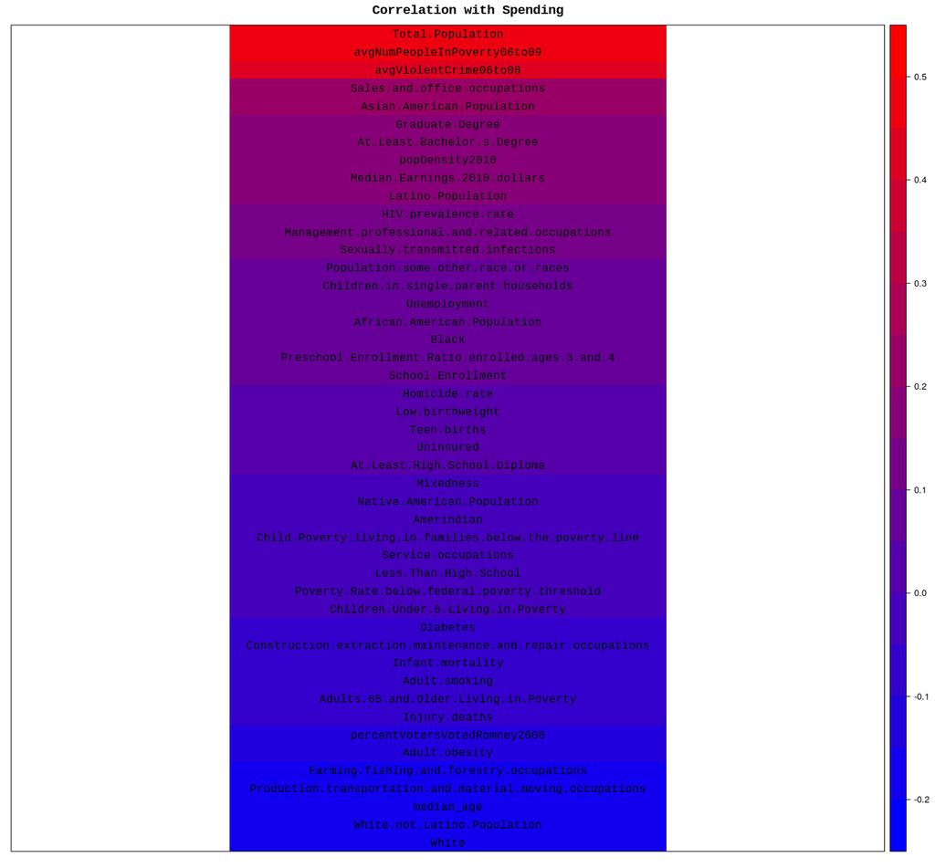

Most of the factors have correlation coefficients very close to 0 which implies those factors probably do not have any relationship at all with spending.

The most telling factors are the top three. The positive correlation of total population and spending is somewhat intuitive, however the positive correlation of crime and poverty with spending is more interesting. What this tells us is that poorer, more crime-ridden counties tend to have higher spending on combat-oriented equipment.

There is also a more nuanced relationship explained by the variables with weaker correlations. We see that non-white populations have weak positive correlations and white population has a weak negative correlation, median age has a weak negative correlation, population density has a weak positive correlation and white collar occupations have weak positive correlation while blue collar occupations have weak negative correlations. What does all of this tell us? Counties that are whiter, more rural, older and more blue collar tend to have less spending on combat-oriented equipment than less white, more white collar and more urban ones do.

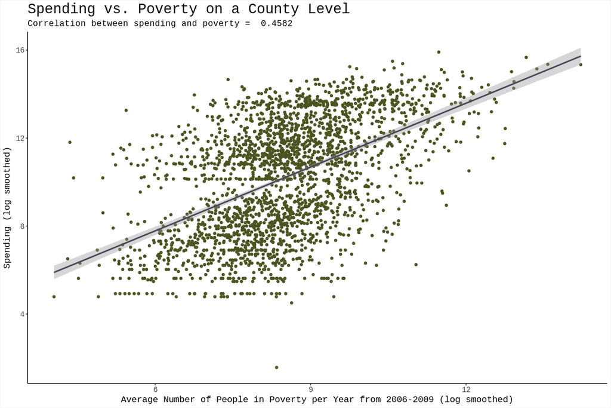

```r
ggplot(counties_df, aes(x = log(poverty), y = log(spending))) +
  military_theme + theme(plot.title = element_text(hjust = 0)) +
  geom_point(colour="#4b5320") + geom_smooth(method='lm', formula=y~x, colour="#454955") +
  xlab("Average Number of People in Poverty per Year from 2006-2009 (log smoothed)") + ylab("Spending (log smoothed)") +
  ggtitle(label="Spending vs. Poverty on a County Level",
          subtitle=paste("Correlation between spending and poverty = ", spendPovCor))
```

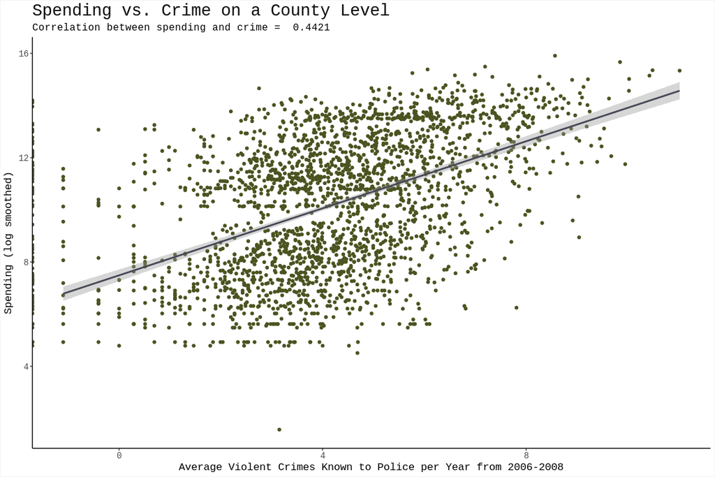

```r
suppressWarnings(
ggplot(counties_df, aes(x = log(crime), y = log(spending))) +
  military_theme + theme(plot.title = element_text(hjust = 0)) +
  geom_point(colour="#4b5320") + geom_smooth(method='lm', formula=y~x, colour="#454955") +
  xlab("Average Violent Crimes Known to Police per Year from 2006-2008") + ylab("Spending (log smoothed)") +
  ggtitle(label="Spending vs. Crime on a County Level",
          subtitle=paste("Correlation between spending and crime = ", spendCrimeCor)))
```

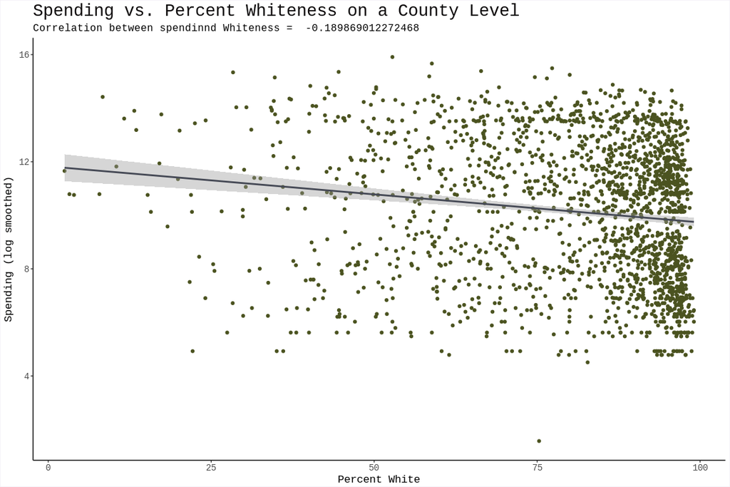

```r
suppressWarnings(
ggplot(USA_county_delta, aes(x = White, y = log(spending))) +
  military_theme + theme(plot.title = element_text(hjust = 0)) +
  geom_point(colour="#4b5320") + geom_smooth(method='lm', formula=y~x, colour="#454955") +
  xlab("Percent White") + ylab("Spending (log smoothed)") +
  ggtitle(label="Spending vs. Percent Whiteness on a County Level",
          subtitle=paste("Correlation between spendinnd Whiteness = ", spending_cors["White"])))
```

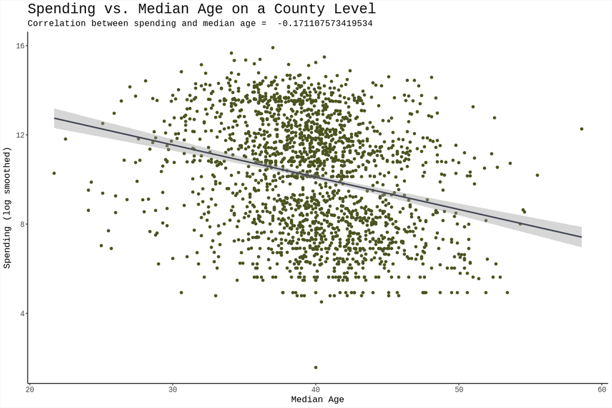